# AT4

[figure not shown]

```r
barplot(top_acetobacter$RSCU, names.arg = top_acetobacter$codon, main = "A. aceti - Top 20 Preferred Codons",ylab = "RSCU", col = "red")
```

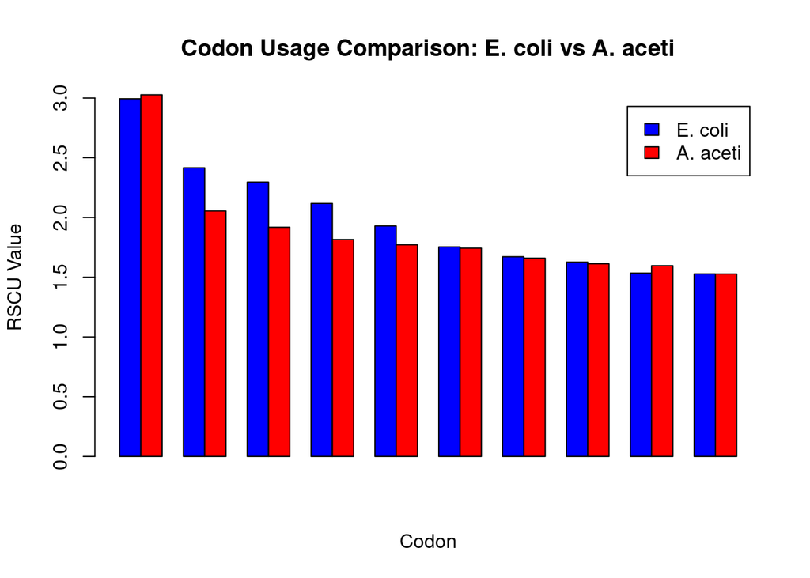

```r
barplot (rbind(top_ecoli$RSCU, top_acetobacter$RSCU), beside = TRUE, col = c("blue", "red"), main = "Codon Usage Comparison: E. coli vs A. aceti", ylab = "RSCU Value", xlab = "Codon", legend = c("E. coli", "A. aceti"))
```

# Question 6 # K-mer profiling K-mer is simply a short sequence string of length k. We can use k-mer analysis to identify particular sequences that are over- or under-represented in an organism. # 3-mer Firsly, I did analysis for 3-Mers. The code below was used for 3-Mer profiling of A. aceti. It extracts all protein sequences, removes stop codons (*), identifies unique amino acids, then counts all possible 3-amino-acid combinations using both absolute frequencies and relative proportions to characterize peptide motifs in the proteome.

```r
acetobacter_prots <- unlist(acetobacter_prot)
Aaa <- unique(acetobacter_prots)
Aaa <- Aaa[Aaa != "*"]
acetobacter_3mer <- count(acetobacter_prots, wordsize = 3, alphabet = Aaa)
str(acetobacter_3mer)
```

```
##  'table' int [1:8000(1d)] 1685 215 631 749 539 1232 308 796 393 1713 ...
##  - attr(*, "dimnames")=List of 1
##   ..$ : chr [1:8000] "AAA" "AAC" "AAD" "AAE" ...
```

```r
acetobacter_3mer_freq <- count(acetobacter_prots, wordsize = 3, alphabet = Aaa, freq = TRUE)
```

# E.coli 3-mer profiling

Similarily, the 3-mer profiling was done for E. coli, using the codes given below.

```r
ecoli_prots <- unlist(ecoli_prot)
aa <- unique(ecoli_prots)
aa <- aa[aa != "*"]
ecoli_3mer <- count(ecoli_prots, wordsize = 3, alphabet = aa)
str(ecoli_3mer)
```

```
##  'table' int [1:8000(1d)] 1338 182 568 749 481 1075 222 863 580 1594 ...
##  - attr(*, "dimnames")=List of 1
##   ..$ : chr [1:8000] "AAA" "AAC" "AAD" "AAE" ...
```

```r
ecoli_3mer_freq <- count(ecoli_prots, wordsize = 3, alphabet = aa, freq = TRUE)
```

#The most over-represented 3-mers The most overexpressed 3-mers were found using the following code. “acetobacter_3mer_freq” was sorted in decreasing order and first 10 lines were used and then placed in over_aceti3.

```r
over_aceti3 <- head(sort(acetobacter_3mer_freq, decreasing = TRUE), 10)
print("Most over-represented 3-mers in A.aceti:")
```

```
## [1] "Most over-represented 3-mers in A.aceti:"
```

```r
print(over_aceti3)
```

```
##
##         AAL         AAA         ALA         LAA         ALL         LLA
## 0.001602957 0.001576756 0.001537454 0.001500023 0.001311936 0.001259533
##         AGL         AAG         LAL         LAG
## 0.001158471 0.001152856 0.001095775 0.001072381
```

#The most under-represented 3-mers Similarily, the most underexpressed 3-mers were found using the following code. “acetobacter_3mer_freq” was sorted in increasing order and first 10 lines were used and then placed in under_aceti3, which was later printed using print().

```r
under_aceti3 <- head(sort(acetobacter_3mer_freq, decreasing = FALSE), 10)
print("Most under-represented 3-mers in A.aceti:")
```

```
## [1] "Most under-represented 3-mers in A.aceti:"
```

```r
print(under_aceti3)
```

```
##
##          CMY          CQC          KCC          MCY          WKC          WWC
## 9.357601e-07 9.357601e-07 9.357601e-07 9.357601e-07 9.357601e-07 9.357601e-07
##          YCK          CCC          CCM          CHW
## 9.357601e-07 1.871520e-06 1.871520e-06 1.871520e-06
```

# Comparision with E. coli

Then these specific k-mers were compared with that of E.coli. “names(over_aceti3)” function helped to find these specific kmers in “ecoli_3mer” and these were viwed and printed using head() and print() commands specifying the number of lines to be dispalyed(10). These contents were moved to files aceto3, aceto3u and ecoli3 , ecoli3u (u was used for undrepresented data files). Comaparative plots were created using the code given below , barplot(). It is evident from the barplots that there is not much difference in both the organisms. Most of the similar 3-mers are overexpressed in both organism. Same observation was made for Underexpressed 3-mers.

```r
print ("Overexpressed 3-mers")
```

```
## [1] "Overexpressed 3-mers"
```

```r
head(ecoli_3mer[names(over_aceti3)],10)
```

```
##
##  AAL  AAA  ALA  LAA  ALL  LLA  AGL  AAG  LAL  LAG
## 1594 1338 1740 1601 1744 1817 1081 1075 1536 1178
```

```r
print ("Underexpressed 3-mers")
```

```
## [1] "Underexpressed 3-mers"
```

```r
head(ecoli_3mer[names(under_aceti3)],10)
```

```
##
## CMY CQC KCC MCY WKC WWC YCK CCC CCM CHW
##   1   7   6  11   4   2  13   9   4   3
```

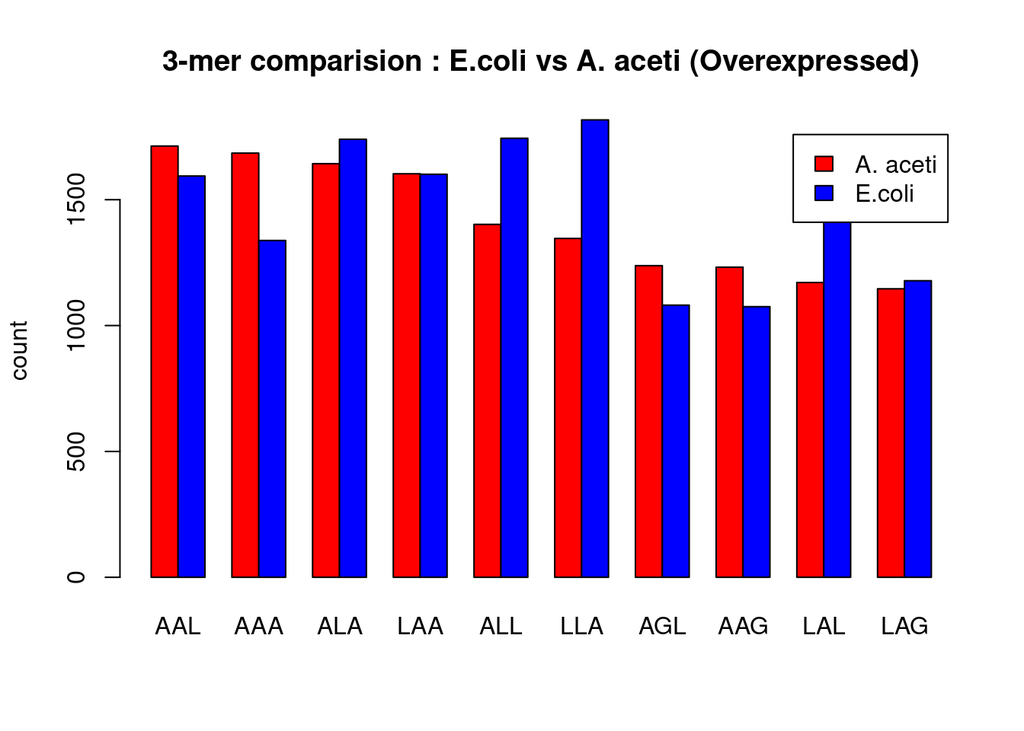

```r
aceto3 <- acetobacter_3mer[names(over_aceti3)]
ecoli3 <- ecoli_3mer[names(over_aceti3)]
barplot (rbind(aceto3,ecoli3), beside = TRUE, names.arg = names(over_aceti3), col = c("red", "blue"), main = "3-mer comparision : E.coli vs A. aceti (Overexpressed)", ylab = "count", legend= c("A. aceti", "E.coli"))
```

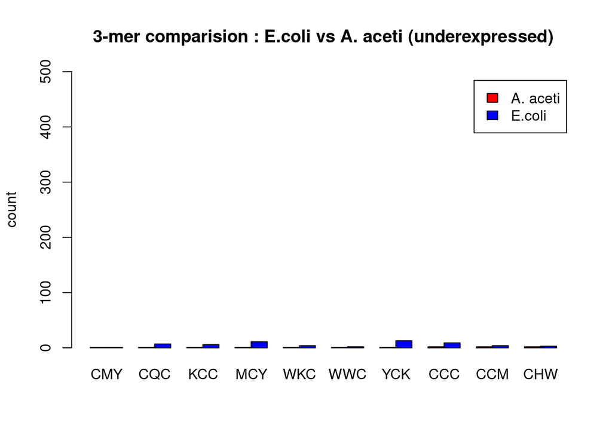

```r
aceto3u <- acetobacter_3mer[names(under_aceti3)]
ecoli3u <- ecoli_3mer[names(under_aceti3)]
barplot (rbind(aceto3u,ecoli3u),ylim = c(0, 500), beside = TRUE, names.arg = names(under_aceti3), col = c("red", "blue"), main = "3-mer comparision : E.coli vs A. aceti (underexpressed)", ylab = "count", legend= c("A. aceti", "E.coli"))
```

# 4-mers

Same approach was used for 4-mers. Just replaced 3 by 4.

```r
acetobacter_4mer <- count(acetobacter_prots, wordsize = 4, alphabet = Aaa)
str(acetobacter_4mer)
```

```
##  'table' int [1:160000(1d)] 223 21 59 107 59 139 40 90 64 211 ...
##  - attr(*, "dimnames")=List of 1
##   ..$ : chr [1:160000] "AAAA" "AAAC" "AAAD" "AAAE" ...
```

```r
acetobacter_4mer_freq <- count(acetobacter_prots, wordsize = 4, alphabet = Aaa, freq = TRUE)
```

# E.coli 4-mers

```r
ecoli_4mer <- count(ecoli_prots, wordsize = 4, alphabet = aa)
str(ecoli_4mer)
```

```
##  'table' int [1:160000(1d)] 148 20 56 76 38 100 24 88 70 172 ...
##  - attr(*, "dimnames")=List of 1
##   ..$ : chr [1:160000] "AAAA" "AAAC" "AAAD" "AAAE" ...
```

```r
ecoli_4mer_freq <- count(ecoli_prots, wordsize = 4, alphabet = aa, freq = TRUE)
```

# The most under and over represented 4-mers

```r
over_aceti4 <- head(sort(acetobacter_4mer_freq, decreasing = TRUE), 10)
print("Most over-represented 4-mers in A.aceti:")
```

```
## [1] "Most over-represented 4-mers in A.aceti:"
```

```r
print(over_aceti4)
```

```
##
##         AALA         ALAA         AAAA         LAAL         ALLA         AAAL
## 0.0002130959 0.0002102797 0.0002093409 0.0002074634 0.0001990147 0.0001980759
##         LAAA         LLAA         AGLA         ALAL
## 0.0001933822 0.0001764847 0.0001614647 0.0001605260
```

```r
under_aceti4 <- head(sort(acetobacter_4mer_freq, decreasing = FALSE), 10)
print("Most under-represented 4-mers in A.aceti:")
```

```
## [1] "Most under-represented 4-mers in A.aceti:"
```

```r
print(under_aceti4)
```

```
##
## ACCC ACCF ACCG ACCH ACCN ACCP ACCQ ACCR ACCW ACCY
##    0    0    0    0    0    0    0    0    0    0
```

# Comparision with E.coli

```r
print ("Overexpressed 4-mers")
```

```
## [1] "Overexpressed 4-mers"
```

```r
head(ecoli_4mer[names(over_aceti4)],10)
```

```
##
## AALA ALAA AAAA LAAL ALLA AAAL LAAA LLAA AGLA ALAL
##  207  233  148  234  193  172  179  206  120  183
```

```r
print ("Underexpressed 4-mers")
```

```
## [1] "Underexpressed 4-mers"
```

```r
head(ecoli_4mer[names(under_aceti4)],10)
```

```
##
## ACCC ACCF ACCG ACCH ACCN ACCP ACCQ ACCR ACCW ACCY
##    1    0    5    0    1    1    0    1    0    1
```

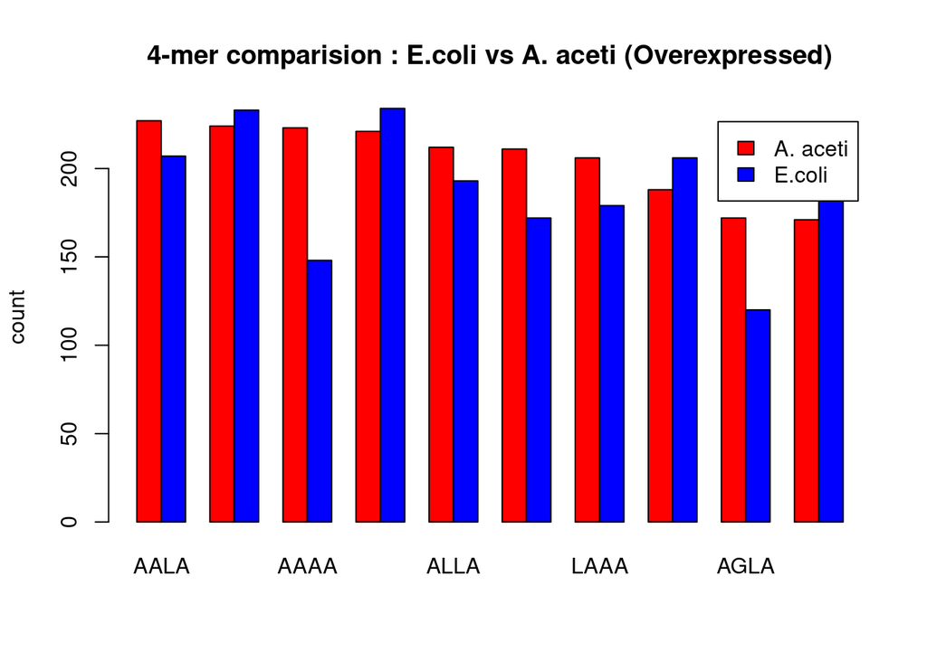

```r
aceto4 <- acetobacter_4mer[names(over_aceti4)]
ecoli4 <- ecoli_4mer[names(over_aceti4)]
barplot (rbind(aceto4,ecoli4), beside = TRUE, names.arg = names(over_aceti4), col = c("red", "blue"), main = "4-mer comparision : E.coli vs A. aceti (Overexpressed)", ylab = "count", legend= c("A. aceti", "E.coli"))
```

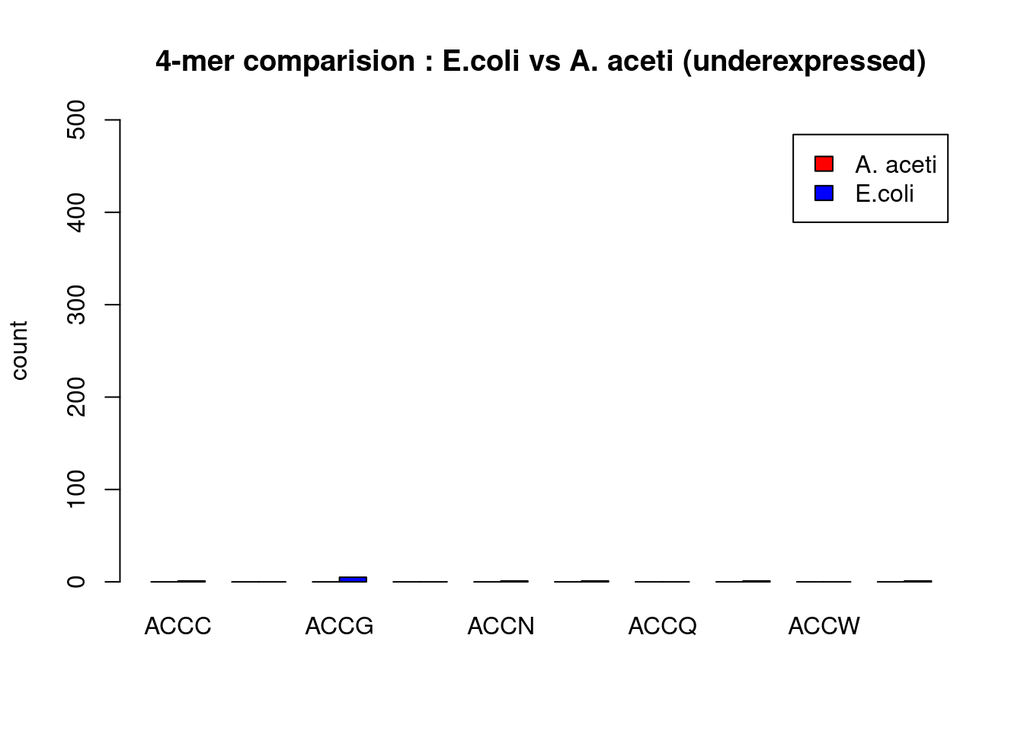

```r
aceto4u <- acetobacter_4mer[names(under_aceti4)]
ecoli4u <- ecoli_4mer[names(under_aceti4)]
barplot (rbind(aceto4u,ecoli4u),ylim = c(0, 500), beside = TRUE, names.arg = names(under_aceti4), col = c("red", "blue"), main = "4-mer comparision : E.coli vs A. aceti (underexpressed)", ylab = "count", legend= c("A. aceti", "E.coli"), )
```

# 5-mers

Same approach was used for 5-mers. Just 3 was replaced by 5 in the commands.

```r
acetobacter_5mer <- count(acetobacter_prots, wordsize = 5, alphabet = Aaa)
str(acetobacter_5mer)
```

```
##  'table' int [1:3200000(1d)] 27 1 6 12 9 25 4 10 7 34 ...
##  - attr(*, "dimnames")=List of 1
##   ..$ : chr [1:3200000] "AAAAA" "AAAAC" "AAAAD" "AAAAE" ...
```

```r
acetobacter_5mer_freq <- count(acetobacter_prots, wordsize = 5, alphabet = Aaa, freq = TRUE)
```

# E. coli 5-mers

```r
ecoli_5mer <- count(ecoli_prots, wordsize = 5, alphabet = aa)
str(ecoli_5mer)
```

```
##  'table' int [1:3200000(1d)] 27 0 5 10 4 13 1 10 10 15 ...
##  - attr(*, "dimnames")=List of 1
##   ..$ : chr [1:3200000] "AAAAA" "AAAAC" "AAAAD" "AAAAE" ...
```

```r
ecoli_5mer_freq <- count(ecoli_prots, wordsize = 5, alphabet = aa, freq = TRUE)
```

# The most under and over represented 5-mers

```r
over_aceti5 <- head(sort(acetobacter_5mer_freq, decreasing = TRUE), 10)
print("Most over-represented 5-mers in A.aceti:")
```

```
## [1] "Most over-represented 5-mers in A.aceti:"
```

```r
print(over_aceti5)
```

```
##
##        GKSTL        AALAA        VSSGG        AAAAL        AAALA        AAALG
## 3.390322e-05 3.296147e-05 3.296147e-05 3.201971e-05 2.919444e-05 2.919444e-05
##        ALAAG        LAAAL        LAALR        AARAA
## 2.919444e-05 2.919444e-05 2.919444e-05 2.731093e-05
```

```r
under_aceti5 <- head(sort(acetobacter_5mer_freq, decreasing = FALSE), 10)
print("Most under-represented 5-mers in A.aceti:")
```

```
## [1] "Most under-represented 5-mers in A.aceti:"
```

```r
print(under_aceti5)
```

```
##
## AAACC AAACD AAACF AAACI AAACM AAACN AAACP AAACQ AAACR AAACW
##     0     0     0     0     0     0     0     0     0     0
```

# Comparision with E.coli

```r
print ("Overexpressed 5-mers")
```

```
## [1] "Overexpressed 5-mers"
```

```r
head(ecoli_5mer[names(over_aceti5)],10)
```

```
##
## GKSTL AALAA VSSGG AAAAL AAALA AAALG ALAAG LAAAL LAALR AARAA
##    58    37     2    15    25    18    27    34    19     8
```

```r
print ("Underexpressed 5-mers")
```

```
## [1] "Underexpressed 5-mers"
```

```r
head(ecoli_5mer[names(under_aceti5)],10)
```

```
##
## AAACC AAACD AAACF AAACI AAACM AAACN AAACP AAACQ AAACR AAACW
##     0     1     1     0     0     0     0     1     1     0
```

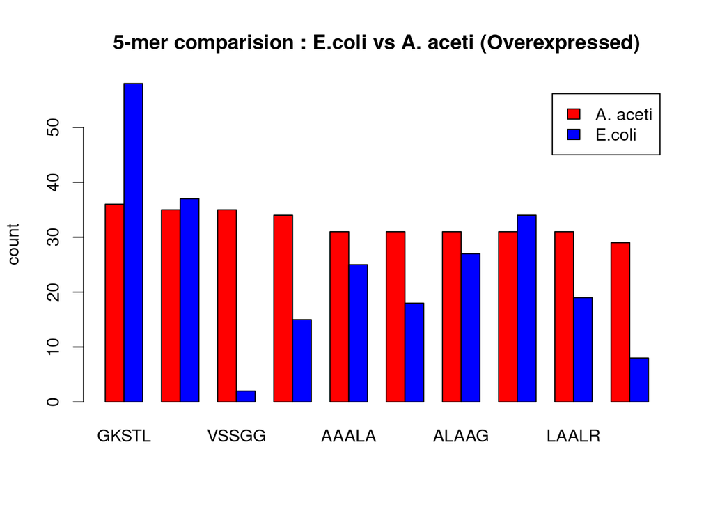

```r
aceto5 <- acetobacter_5mer[names(over_aceti5)]
ecoli5 <- ecoli_5mer[names(over_aceti5)]
barplot (rbind(aceto5,ecoli5), beside = TRUE, names.arg = names(over_aceti5), col = c("red", "blue"), main = "5-mer comparision : E.coli vs A. aceti (Overexpressed)", ylab = "count", legend= c("A. aceti", "E.coli"))
```

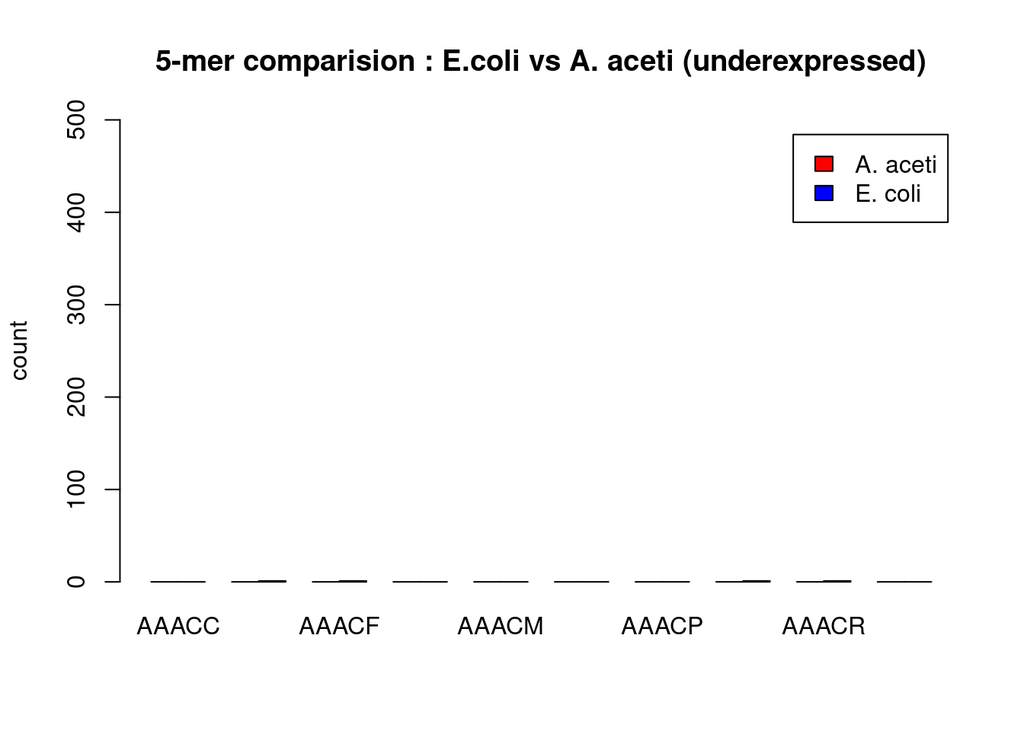

```r
aceto5u <- acetobacter_5mer[names(under_aceti5)]
ecoli5u <- ecoli_5mer[names(under_aceti5)]
barplot (rbind(aceto5u,ecoli5u),ylim = c(0, 500), beside = TRUE, names.arg = names(under_aceti5), col = c("red", "blue"), main = "5-mer comparision : E.coli vs A. aceti (underexpressed)", ylab = "count", legend= c("A. aceti", "E. coli"))
```

#Conclusion This analysis integrated computational biology approaches to analyze both quantitative experimental data (Part 1) and genomic sequence features (Part 2). In Part 1, RNA-seq and tree growth datasets were processed using R for data wrangling, statistical analysis, and visualization — building skills in reproducible research, version control via GitHub, and interpretation of biological trends in gene expression and growth patterns.In Part 2, comparative genomics of Acetobacter aceti and Escherichia coli revealed conserved molecular patterns in GC content, amino acid usage, and codon bias, while also identifying species-specific k-mer signatures likely tied to ecological adaptation. Together, these analyses demonstrate how bioinformatics tools can uncover meaningful biological insights — from differential gene expression and environmental effects on phenotype to evolutionary signals embedded in genomic sequences — while reinforcing essential practices in coding, documentation, and open science.